# Through the eyes of the teacher - Multimodal exploration of expertise differences in the perception of classroom disruptions in a laboratory study

## 1. Participants

Demographic information & teaching experience

| Group | N | Women in percent | M Age in years | SD Age in years | Min Age in years | Max Age in years | M Exp. | SD Exp. | Min Exp. | Max Exp. |
| --- | --- | --- | --- | --- | --- | --- | --- | --- | --- | --- |
| Expert | 40 | 60.00 | 39.10 | 10.55 | 26 | 60 | 11.55 | 11.32 | 1 | 38 |
| Novice | 42 | 69.05 | 22.83 | 1.85 | 19 | 27 | 0.00 | 0.00 | 0 | 0 |

## 2. Measures

### 2.1 Eye-Tracking Data

#### 2.2.1 Number of fixation (micro-teaching unit)

N, M, SD, min & max number of fixations (micro-teaching unit)

| Group | N | M | SD | Min | Max |
| --- | --- | --- | --- | --- | --- |
| Novice | 42 | 1622.9 | 256.14 | 1223 | 2201 |
| Expert | 40 | 1753.8 | 331.51 | 859 | 2427 |

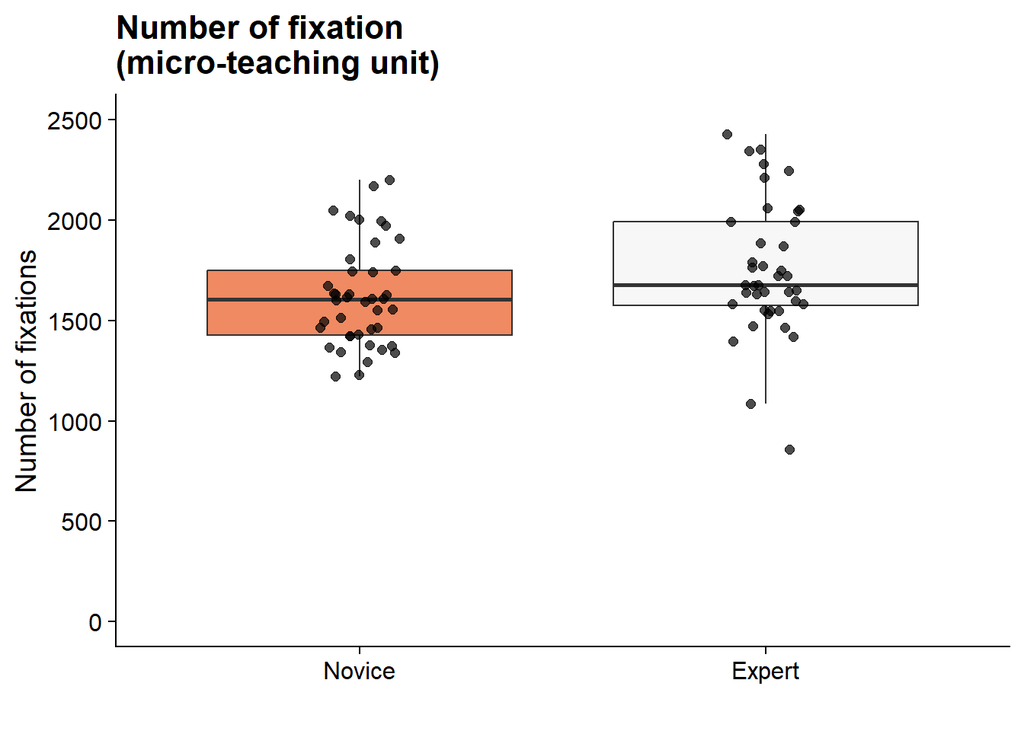

#### t-test & effect size “Number of fixation (micro-teaching unit)”

```
Two Sample t-test
```

data: df_aoi_sum$Sum_number_fixation[df_aoi_sum$Group == “Expert”] and df_aoi_sum$Sum_number_fixation[df_aoi_sum$Group == “Novice”] t = 2.0064, df = 80, p-value = 0.04819 alternative hypothesis: true difference in means is not equal to 0 95 percent confidence interval: 1.064543 260.725933 sample estimates: mean of x mean of y 1753.800 1622.905

[1] 0.44 attr(,“magnitude”) [1] “small”

#### 2.2.2 Number of fixations (AOI students)

N, M, SD, min & max number of fixations (AOI students)

| Group | N | M | SD | Min | Max |
| --- | --- | --- | --- | --- | --- |
| Novice | 42 | 711.45 | 202.92 | 297 | 1095 |
| Expert | 40 | 770.32 | 221.05 | 441 | 1328 |

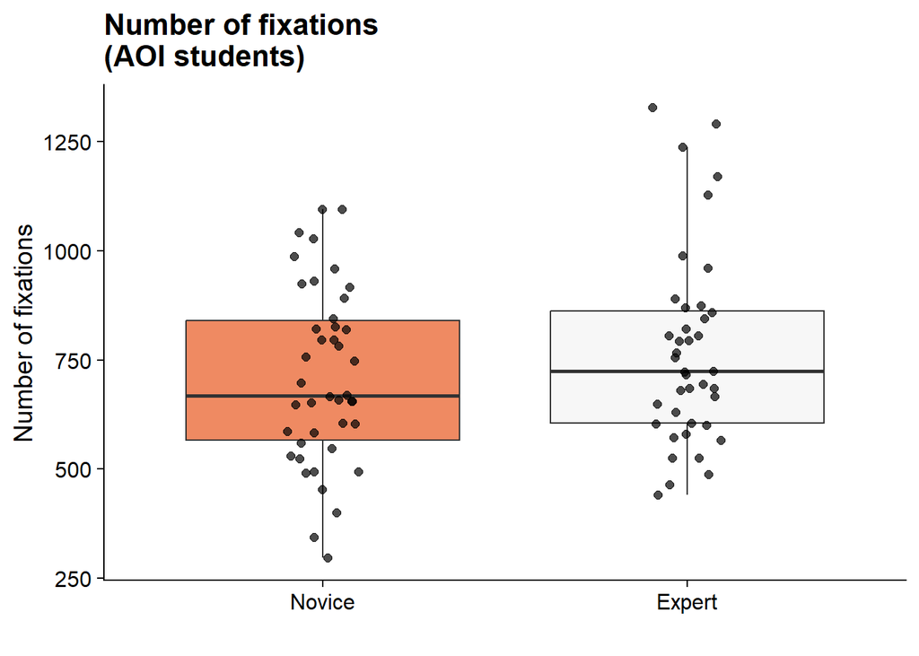

#### t-test & effect size “Number of fixation” (AOI students)

```
Two Sample t-test
```

data: df_aoi_stud$Stud_number_fixation[df_aoi_stud$Group == “Expert”] and df_aoi_stud$Stud_number_fixation[df_aoi_stud$Group == “Novice”] t = 1.2572, df = 80, p-value = 0.2123 alternative hypothesis: true difference in means is not equal to 0 95 percent confidence interval: -34.31519 152.06043 sample estimates: mean of x mean of y 770.3250 711.4524

[1] 0.28 attr(,“magnitude”) [1] “small”

#### 2.2.3 Number of fixations (AOI disruptive person)

N, M, SD, min & max number of fixation (AOI disruptive person)

| Group | N | M | SD | Min | Max |
| --- | --- | --- | --- | --- | --- |
| Novice | 42 | 48.14 | 21.87 | 25 | 133 |
| Expert | 40 | 44.12 | 13.31 | 15 | 88 |

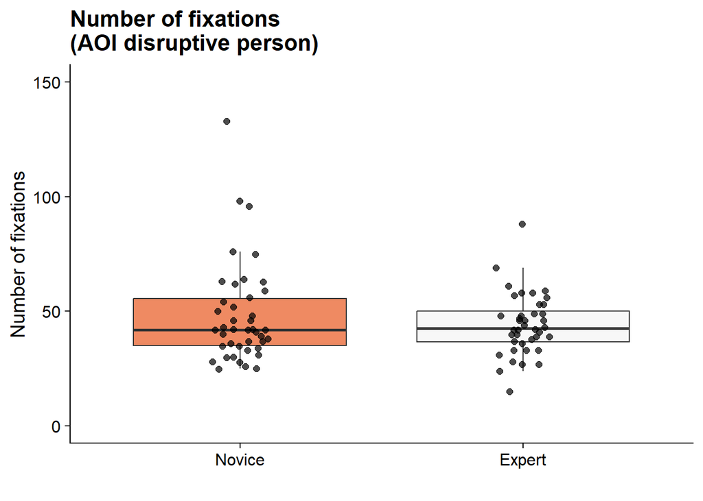

#### t-test & effect size “Number of fixations” (AOI disruptive person)

```
Two Sample t-test
```

data: df_aoi_disrup$Number_of_fixations.Disruptive_Person[df_aoi_disrup$Group == “Expert”] and df_aoi_disrup$Number_of_fixations.Disruptive_Person[df_aoi_disrup$Group == “Novice”] t = -0.99886, df = 80, p-value = 0.3209 alternative hypothesis: true difference in means is not equal to 0 95 percent confidence interval: -12.022778 3.987063 sample estimates: mean of x mean of y 44.12500 48.14286

[1] -0.22 attr(,“magnitude”) [1] “small”

#### 2.2.4 Average duration of fixations in milliseconds (micro-teaching unit)

N, M, SD, min & max duration of fixations in milliseconds (micro-teaching unit)

| Group | N | M in ms | SD in ms | Min in ms | Max in ms |
| --- | --- | --- | --- | --- | --- |
| Novice | 42 | 513.81 | 117.71 | 247 | 749 |
| Expert | 40 | 472.92 | 106.18 | 295 | 712 |

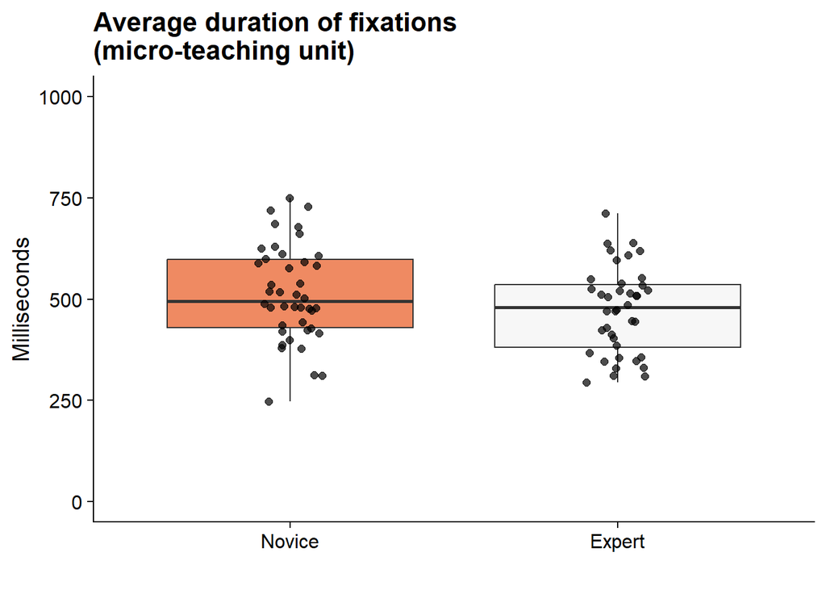

#### t-test & effect size “Average duration of fixations” (micro-teaching unit)

```
Two Sample t-test
```

data: df_aoi_sum$Average_duration_mtu[df_aoi_sum$Group == “Expert”] and df_aoi_sum$Average_duration_mtu[df_aoi_sum$Group == “Novice”] t = -1.6488, df = 80, p-value = 0.1031 alternative hypothesis: true difference in means is not equal to 0 95 percent confidence interval: -90.231822 8.462774 sample estimates: mean of x mean of y 472.9250 513.8095

[1] -0.36 attr(,“magnitude”) [1] “small”

#### 2.2.5 Average duration of fixations (AOI students)

N, M, SD, min & max average duration of fixations in milliseconds (AOI students)

| Group | N | M in ms | SD in ms | Min in ms | Max in ms |
| --- | --- | --- | --- | --- | --- |
| Novice | 42 | 613.67 | 191.19 | 254 | 1115 |
| Expert | 40 | 552.55 | 146.32 | 309 | 925 |

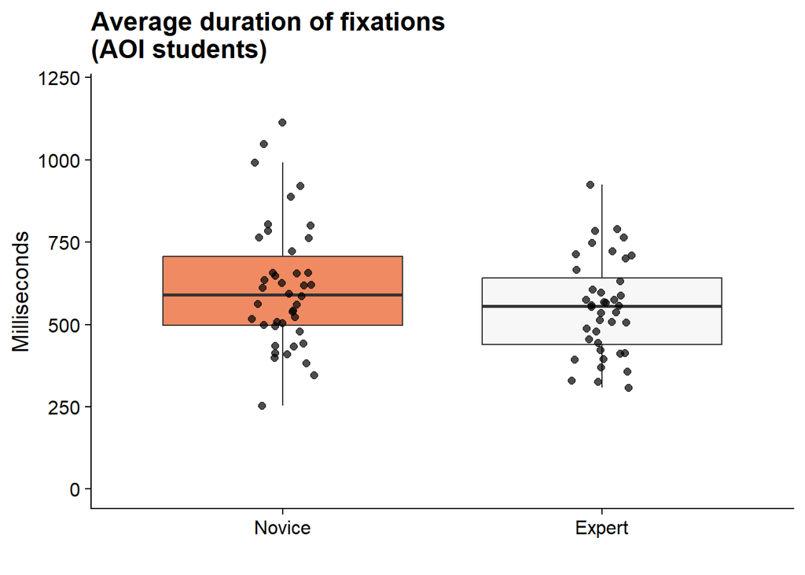

#### t-test & effect size “Average duration of fixations” (AOI students)

```
Two Sample t-test
```

data: df_aoi_stud$Average_duration_stud[df_aoi_stud$Group == “Expert”] and df_aoi_stud$Average_duration_stud[df_aoi_stud$Group == “Novice”] t = -1.6197, df = 80, p-value = 0.1092 alternative hypothesis: true difference in means is not equal to 0 95 percent confidence interval: -136.20902 13.97569 sample estimates: mean of x mean of y 552.5500 613.6667

[1] -0.36 attr(,“magnitude”) [1] “small”

#### 2.2.6 Average duration of fixations (AOI disruptive person)

N, M, SD, min & max average duration of fixations in milliseconds (AOI disruptive person)

| Group | N | M in ms | SD in ms | Min in ms | Max in ms |
| --- | --- | --- | --- | --- | --- |
| Novice | 42 | 584.57 | 216.40 | 266 | 1150 |
| Expert | 40 | 503.05 | 153.92 | 303 | 1081 |

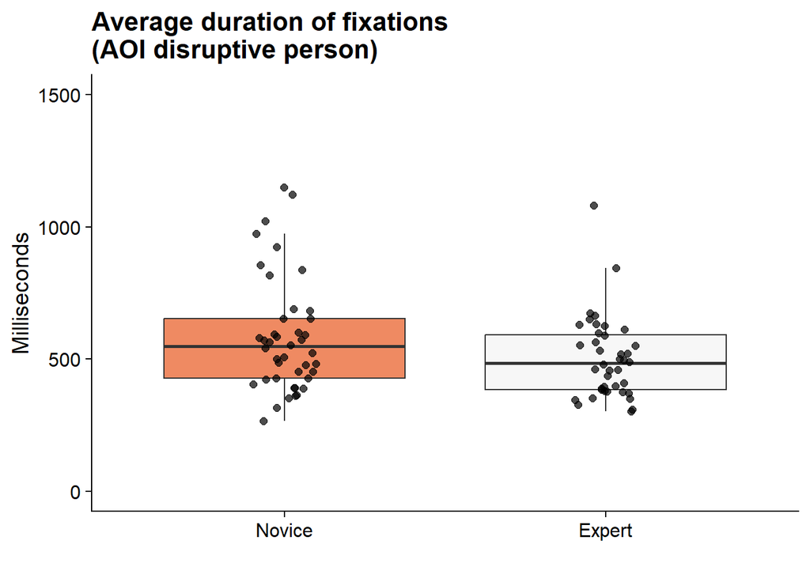

#### t-test & effect size “Average duration of fixations” (AOI disruptive person)

```
Two Sample t-test
```

data: df_aoi_disrup$Average_duration_disrup[df_aoi_disrup$Group == “Expert”] and df_aoi_disrup$Average_duration_disrup[df_aoi_disrup$Group == “Novice”] t = -1.957, df = 80, p-value = 0.05383 alternative hypothesis: true difference in means is not equal to 0 95 percent confidence interval: -164.418963 1.376106 sample estimates: mean of x mean of y 503.0500 584.5714

[1] -0.43 attr(,“magnitude”) [1] “small”

#### 2.2.7 Gaze Relational Index (GRI; micro-teaching unit)

N, M, SD, min & max GRI (micro-teaching unit)

| Group | N | M | SD | Min | Max |
| --- | --- | --- | --- | --- | --- |
| Novice | 42 | 0.33 | 0.12 | 0.12 | 0.61 |
| Expert | 40 | 0.29 | 0.12 | 0.12 | 0.66 |

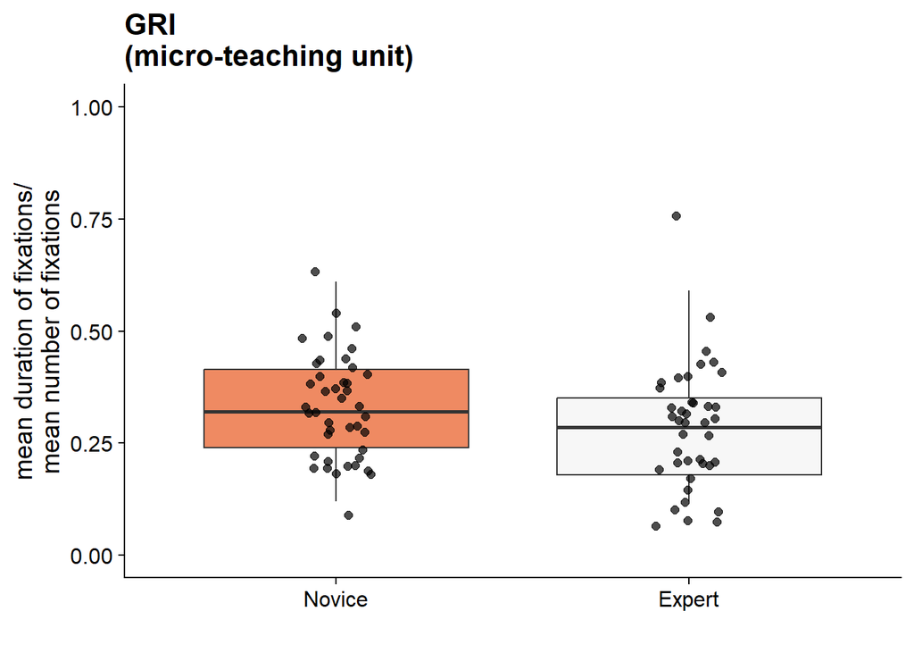

#### t-test & effect size “GRI” (micro-teaching unit)

```
Two Sample t-test
```

data: df_gri$GRI[df_gri$Group == “Expert”] and df_gri$GRI[df_gri$Group == “Novice”] t = -1.6007, df = 80, p-value = 0.1134 alternative hypothesis: true difference in means is not equal to 0 95 percent confidence interval: -0.09504394 0.01030585 sample estimates: mean of x mean of y 0.290250 0.332619

[1] -0.35 attr(,“magnitude”) [1] “small”

#### 2.2.8 Gaze Relational Index (GRI; AOI students)

N, M, SD, min & max GRI (AOI students)

| Group | N | M | SD | Min | Max |
| --- | --- | --- | --- | --- | --- |
| Novice | 42 | 0.96 | 0.46 | 0.24 | 2.46 |
| Expert | 40 | 0.79 | 0.33 | 0.25 | 1.62 |

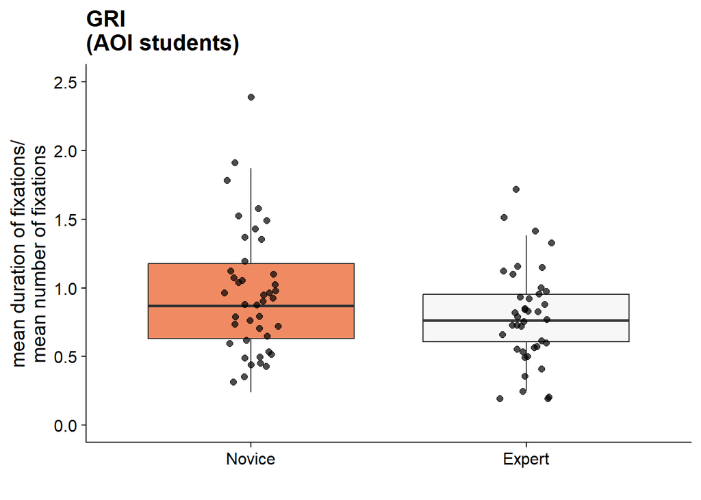

#### t-test & effect size “GRI” (AOI students)

```
Two Sample t-test
```

data: df_gri_stud$GRI_stud[df_gri_stud$Group == “Expert”] and df_gri_stud$GRI_stud[df_gri_stud$Group == “Novice”] t = -1.8771, df = 80, p-value = 0.06416 alternative hypothesis: true difference in means is not equal to 0 95 percent confidence interval: -0.34697220 0.01013887 sample estimates: mean of x mean of y 0.7932500 0.9616667

[1] -0.41 attr(,“magnitude”) [1] “small”

#### 2.2.9 Gaze Relational Index (GRI; AOI disruptive person)

N, M, SD, min & max GRI (AOI disruptive person)

| Group | N | M | SD | Min | Max |
| --- | --- | --- | --- | --- | --- |
| Novice | 42 | 14.36 | 8.30 | 4.08 | 41.07 |
| Expert | 40 | 13.01 | 8.08 | 5.03 | 44.93 |

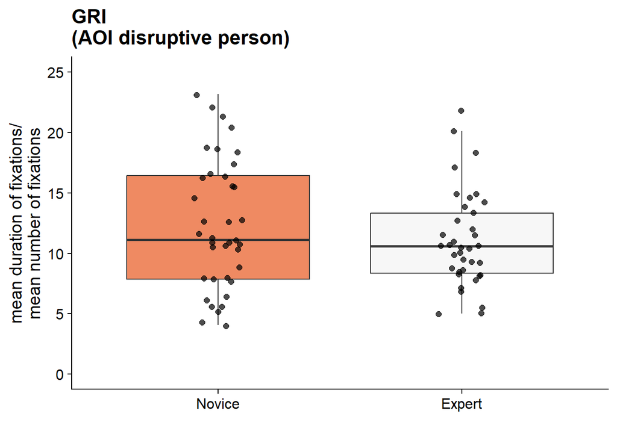

#### t-test & effect size “GRI” (AOI disruptive person)

```
Two Sample t-test
```

data: df_gri_disrup$GRI_disrup[df_gri_disrup$Group == “Expert”] and df_gri_disrup$GRI_disrup[df_gri_disrup$Group == “Novice”] t = -0.74282, df = 80, p-value = 0.4598 alternative hypothesis: true difference in means is not equal to 0 95 percent confidence interval: -4.944305 2.256495 sample estimates: mean of x mean of y 13.0130 14.3569

[1] -0.16 attr(,“magnitude”) [1] “negligible”

#### 2.2.10 Time to first fixation in seconds (AOI disruptive person)

N, M, SD, min & max time to first fixation in seconds (AOI disruptive person)

| Group | N | M in sec | SD in sec | Min in sec | Max in sec |
| --- | --- | --- | --- | --- | --- |
| Novice | 42 | 180.45 | 26.13 | 120.86 | 296.02 |
| Expert | 40 | 178.45 | 18.07 | 143.58 | 261.10 |

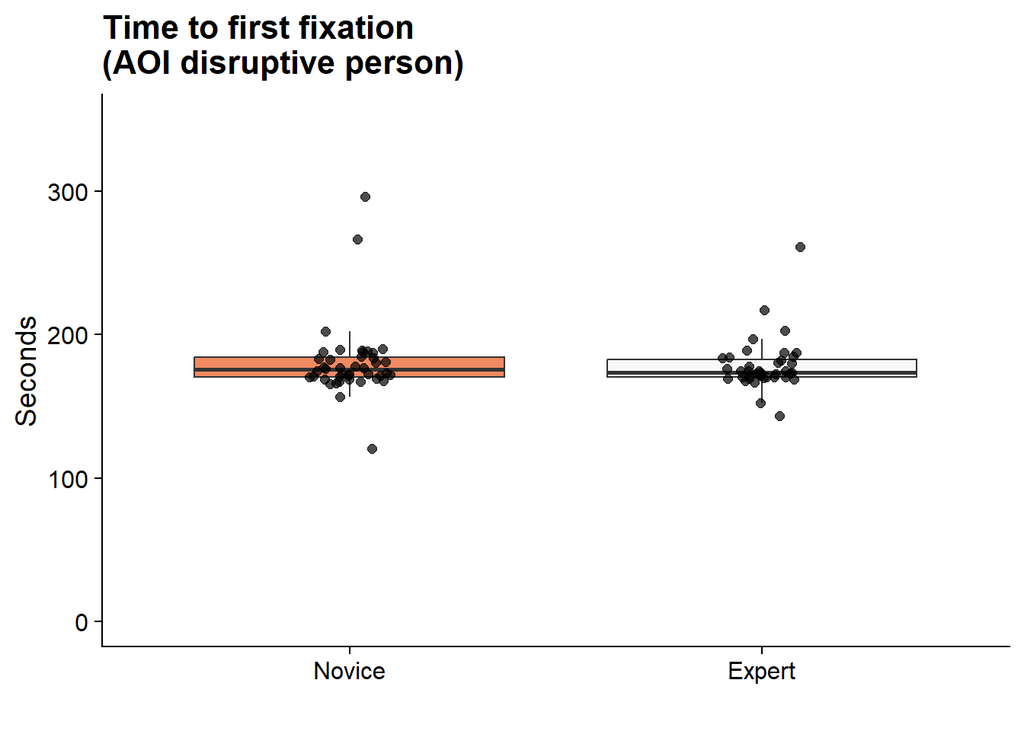

#### t-test & effect size “Time to first fixation” (AOI disruptive person)

```
Two Sample t-test
```

data: df_ttff_disrup$Disrup_time_fixation_sec[df_ttff_disrup$Group == “Expert”] and df_ttff_disrup$Disrup_time_fixation_sec[df_ttff_disrup$Group == “Novice”] t = -0.40114, df = 80, p-value = 0.6894 alternative hypothesis: true difference in means is not equal to 0 95 percent confidence interval: -11.922128 7.922128 sample estimates: mean of x mean of y 178.45 180.45

[1] -0.09 attr(,“magnitude”) [1] “negligible”

### 2.2 Rating Scales (Disruption Appraisal, Confidence Appraisal, Prevalence Rating)

Disruption Appraisal

| ID | N | M | SD | Min | Max |
| --- | --- | --- | --- | --- | --- |
| Expert | 352 | 4.84 | 2.90 | 0 | 10 |
| Novice | 357 | 5.55 | 2.81 | 0 | 10 |

Disruption appraisal with event

| ID | event | N | M | SD | Min | Max |
| --- | --- | --- | --- | --- | --- | --- |
| Expert | chatting | 41 | 6.78 | 2.53 | 1 | 10 |
| Expert | clicking pen | 38 | 5.34 | 2.60 | 0 | 10 |
| Expert | drawing | 35 | 1.80 | 1.89 | 0 | 7 |
| Expert | drumming | 39 | 4.95 | 2.45 | 1 | 10 |
| Expert | head on table | 40 | 4.12 | 2.56 | 0 | 10 |
| Expert | heckling | 41 | 6.29 | 2.69 | 2 | 10 |
| Expert | looking at phone | 36 | 4.94 | 2.89 | 0 | 10 |
| Expert | snipping | 41 | 3.85 | 3.08 | 0 | 10 |
| Expert | whispering | 41 | 5.07 | 2.46 | 0 | 9 |
| Novice | chatting | 42 | 8.12 | 2.04 | 0 | 10 |
| Novice | clicking pen | 40 | 6.28 | 2.51 | 0 | 10 |
| Novice | drawing | 35 | 2.14 | 1.48 | 0 | 5 |
| Novice | drumming | 40 | 6.47 | 2.08 | 0 | 10 |
| Novice | head on table | 40 | 4.15 | 1.81 | 1 | 8 |
| Novice | heckling | 41 | 6.98 | 2.62 | 2 | 10 |
| Novice | looking at phone | 35 | 4.14 | 2.00 | 0 | 8 |
| Novice | snipping | 42 | 4.38 | 2.92 | 0 | 9 |
| Novice | whispering | 42 | 6.55 | 2.19 | 1 | 10 |

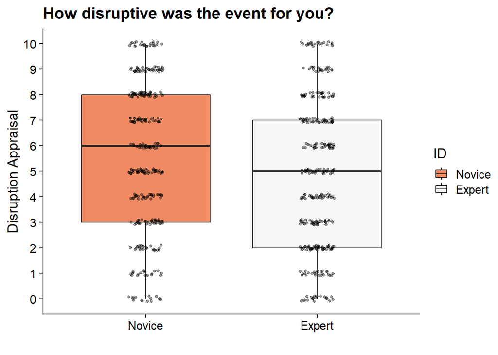

#### t-Test & effect size “Disruption appraisal”

```
Two Sample t-test
```

data: sri$disruption_appraisal[sri$ID == “Expert”] and sri$disruption_appraisal[sri$ID == “Novice”] t = -3.3143, df = 707, p-value = 0.0009655 alternative hypothesis: true difference in means is not equal to 0 95 percent confidence interval: -1.1320397 -0.2897835 sample estimates: mean of x mean of y 4.840909 5.551821

[1] -0.25 attr(,“magnitude”) [1] “small”

Confidence appraisal

| ID | M | SD | Min | Max |
| --- | --- | --- | --- | --- |
| Expert | 8.42 | 1.70 | 2 | 10 |
| Novice | 7.18 | 2.04 | 0 | 10 |

Confidence appraisal with event

| ID | event | N | M | SD | Min | Max |
| --- | --- | --- | --- | --- | --- | --- |
| Expert | chatting | 41 | 8.10 | 1.76 | 2 | 10 |
| Expert | clicking pen | 38 | 8.50 | 1.25 | 5 | 10 |
| Expert | drawing | 35 | 9.23 | 1.00 | 5 | 10 |
| Expert | drumming | 39 | 8.74 | 1.21 | 6 | 10 |
| Expert | head on table | 40 | 8.72 | 1.22 | 5 | 10 |
| Expert | heckling | 41 | 6.78 | 2.41 | 2 | 10 |
| Expert | looking at phone | 36 | 8.75 | 1.44 | 4 | 10 |
| Expert | snipping | 41 | 8.83 | 1.60 | 4 | 10 |
| Expert | whispering | 41 | 8.32 | 1.71 | 3 | 10 |
| Novice | chatting | 42 | 6.69 | 1.97 | 0 | 10 |
| Novice | clicking pen | 40 | 7.40 | 1.72 | 3 | 10 |
| Novice | drawing | 35 | 8.63 | 1.29 | 5 | 10 |
| Novice | drumming | 40 | 7.32 | 2.12 | 1 | 10 |
| Novice | head on table | 40 | 7.03 | 1.78 | 3 | 10 |
| Novice | heckling | 41 | 5.41 | 2.55 | 1 | 10 |
| Novice | looking at phone | 35 | 7.34 | 1.59 | 3 | 10 |
| Novice | snipping | 42 | 8.02 | 1.63 | 3 | 10 |
| Novice | whispering | 42 | 7.05 | 1.91 | 2 | 10 |

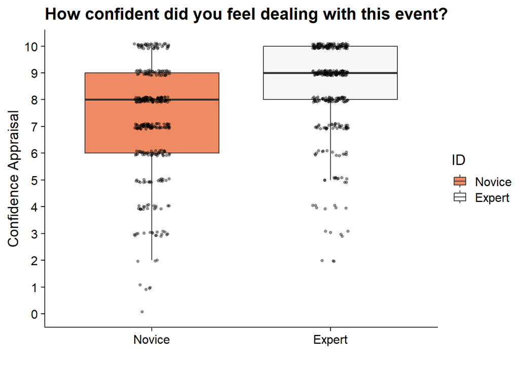

#### t-Test & effect size “Confidence appraisal”

```
Two Sample t-test
```

data: sri$confidence_appraisal[sri$ID == “Expert”] and sri$confidence_appraisal[sri$ID == “Novice”] t = 8.766, df = 707, p-value < 2.2e-16 alternative hypothesis: true difference in means is not equal to 0 95 percent confidence interval: 0.9588466 1.5123145 sample estimates: mean of x mean of y 8.420455 7.184874

[1] 0.66 attr(,“magnitude”) [1] “medium”

Prevalence rating

| ID | N | M | SD | Min | Max |
| --- | --- | --- | --- | --- | --- |
| Expert | 352 | 6.53 | 2.72 | 1 | 10 |
| Novice | 357 | 7.02 | 2.20 | 1 | 10 |

Prevalence rating with events

| ID | event | N | M | SD | Min | Max |
| --- | --- | --- | --- | --- | --- | --- |
| Expert | chatting | 41 | 6.41 | 2.61 | 2 | 10 |
| Expert | clicking pen | 38 | 5.76 | 2.54 | 1 | 10 |
| Expert | drawing | 35 | 8.43 | 1.77 | 3 | 10 |
| Expert | drumming | 39 | 6.00 | 2.56 | 1 | 10 |
| Expert | head on table | 40 | 6.05 | 2.59 | 1 | 10 |
| Expert | heckling | 41 | 5.15 | 2.70 | 1 | 10 |
| Expert | looking at phone | 36 | 7.03 | 2.52 | 1 | 10 |
| Expert | snipping | 41 | 5.27 | 2.77 | 1 | 10 |
| Expert | whispering | 41 | 8.95 | 1.40 | 5 | 10 |
| Novice | chatting | 42 | 6.86 | 2.18 | 1 | 10 |
| Novice | clicking pen | 40 | 6.85 | 2.02 | 3 | 10 |
| Novice | drawing | 35 | 8.40 | 1.48 | 4 | 10 |
| Novice | drumming | 40 | 5.47 | 2.14 | 1 | 10 |
| Novice | head on table | 40 | 6.62 | 1.85 | 3 | 10 |
| Novice | heckling | 41 | 5.76 | 2.32 | 2 | 10 |
| Novice | looking at phone | 35 | 7.26 | 2.05 | 3 | 10 |
| Novice | snipping | 42 | 7.05 | 1.96 | 3 | 10 |
| Novice | whispering | 42 | 9.05 | 1.23 | 4 | 10 |

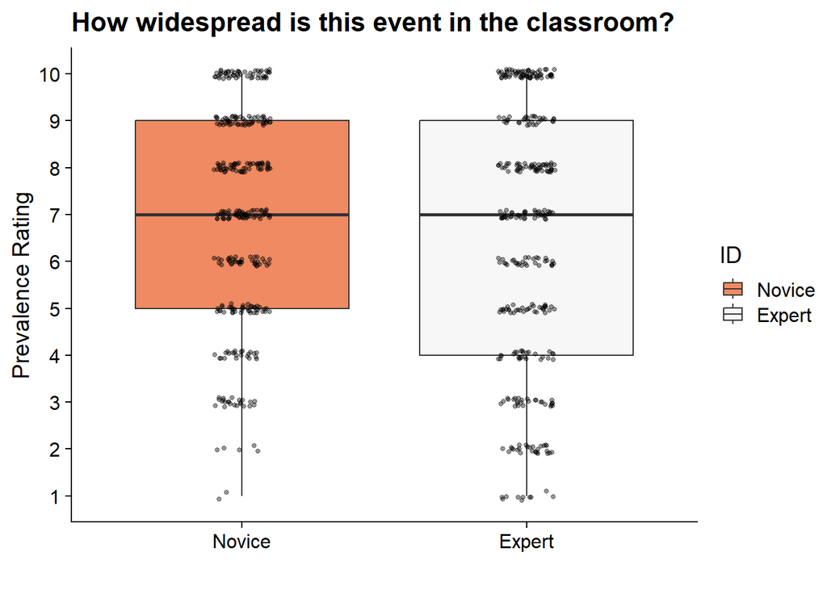

#### t-Test & effect size “Prevalence rating”

```
Two Sample t-test
```

data: sri$prevalence_rating[sri$ID == “Expert”] and sri$prevalence_rating[sri$ID == “Novice”] t = -2.6154, df = 707, p-value = 0.009103 alternative hypothesis: true difference in means is not equal to 0 95 percent confidence interval: -0.8499891 -0.1210448 sample estimates: mean of x mean of y 6.534091 7.019608

[1] -0.2 attr(,“magnitude”) [1] “negligible”

### 2.3 Situational Jugdement Test

N, M and SD for overall value

| Group | N | M | SD | Min | Max |
| --- | --- | --- | --- | --- | --- |
| Expert | 41 | 0.75 | 0.08 | 0.54 | 0.88 |
| Novice | 42 | 0.72 | 0.13 | 0.10 | 0.91 |

N, M and SD for managing momentum

| Group | N | M | SD | Min | Max |
| --- | --- | --- | --- | --- | --- |
| Expert | 41 | 0.81 | 0.10 | 0.60 | 1 |
| Novice | 42 | 0.80 | 0.17 | 0.08 | 1 |

N, M and SD for monitoring

[output not shown]

N, M and SD for rules and routines

[output not shown]

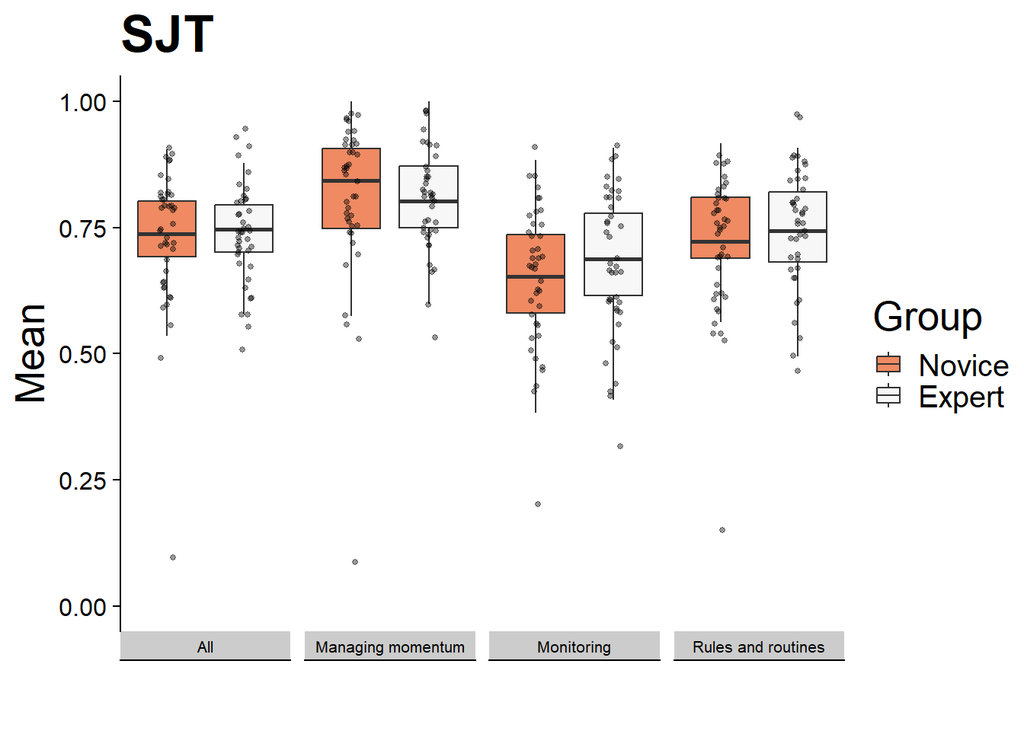

#### t-test & effect size “STJ - All”

```
Two Sample t-test
```

data: df_sjt$All[df_sjt$Group == “Expert”] and df_sjt$All[df_sjt$Group == “Novice”] t = 0.94245, df = 81, p-value = 0.3488 alternative hypothesis: true difference in means is not equal to 0 95 percent confidence interval: -0.02434447 0.06816136 sample estimates: mean of x mean of y 0.7456548 0.7237464

[1] 0.21 attr(,“magnitude”) [1] “small”

#### t-test & effect size “SJT - Managing momentum”

```
Two Sample t-test
```

data: df_sjt$`Managing momentum`[df_sjt$Group == “Expert”] and df_sjt$`Managing momentum`[df_sjt$Group == “Novice”] t = 0.15193, df = 81, p-value = 0.8796 alternative hypothesis: true difference in means is not equal to 0 95 percent confidence interval: -0.05469659 0.06374016 sample estimates: mean of x mean of y 0.8092270 0.8047052

[1] 0.03 attr(,“magnitude”) [1] “negligible”

#### t-test & effect size “SJT - Monitoring”

```
Two Sample t-test
```

data: df_sjt$Monitoring[df_sjt$Group == “Expert”] and df_sjt$Monitoring[df_sjt$Group == “Novice”] t = 1.4415, df = 81, p-value = 0.1533 alternative hypothesis: true difference in means is not equal to 0 95 percent confidence interval: -0.01732034 0.10841421 sample estimates: mean of x mean of y 0.6877186 0.6421717

[1] 0.32 attr(,“magnitude”) [1] “small”

#### t-test & effect size “SJT - Rules & routines”

```
Two Sample t-test
```

data: df_sjt$`Rules and routines`[df_sjt$Group == “Expert”] and df_sjt$`Rules and routines`[df_sjt$Group == “Novice”] t = 0.59927, df = 81, p-value = 0.5507 alternative hypothesis: true difference in means is not equal to 0 95 percent confidence interval: -0.03632644 0.06763970 sample estimates: mean of x mean of y 0.7400189 0.7243622

[1] 0.13 attr(,“magnitude”) [1] “negligible”

### 2.4 Classroom Questionnaire

Mean, SD, min, max for classroom managament (cm) and non-/paraverbal communication (n&pv com)

| Group | N | M cm | SD cm | Min cm | Max cm | M n&pv com | SD n&pv com | Min n&pv com | Max n&pv com |
| --- | --- | --- | --- | --- | --- | --- | --- | --- | --- |
| Expert | 41 | 3.2 | 0.72 | 1 | 4 | 3.30 | 0.65 | 1 | 4 |
| Novice | 42 | 3.0 | 0.77 | 1 | 4 | 3.13 | 0.73 | 1 | 4 |

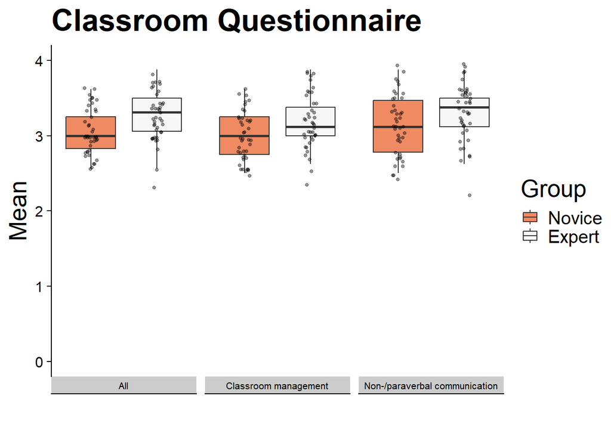

#### t-test & effect size “Classroom Questionnaire - All”

```
Two Sample t-test
```

data: df_quest_plot$All[df_quest_plot$Group == “Expert”] and df_quest_plot$All[df_quest_plot$Group == “Novice”] t = 2.7419, df = 81, p-value = 0.007516 alternative hypothesis: true difference in means is not equal to 0 95 percent confidence interval: 0.05014992 0.31545984 sample estimates: mean of x mean of y 3.247805 3.065000

[1] 0.6 attr(,“magnitude”) [1] “medium”

#### t-test & effect size “Classroom Questionnaire - Classroom Management”

```
Two Sample t-test
```

data: df_quest_plot$`Classroom management`[df_quest_plot$Group == “Expert”] and df_quest_plot$`Classroom management`[df_quest_plot$Group == “Novice”] t = 2.6421, df = 81, p-value = 0.009887 alternative hypothesis: true difference in means is not equal to 0 95 percent confidence interval: 0.04912362 0.34875094 sample estimates: mean of x mean of y 3.195366 2.996429

[1] 0.58 attr(,“magnitude”) [1] “medium”

#### t-test & effect size “Classroom Questionnaire - Non-/paraverbal communication”

```
Two Sample t-test
```

data: df_quest_plot$`Non-/paraverbal communication`[df_quest_plot$Group == “Expert”] and df_quest_plot$`Non-/paraverbal communication`[df_quest_plot$Group == “Novice”] t = 1.997, df = 81, p-value = 0.04919 alternative hypothesis: true difference in means is not equal to 0 95 percent confidence interval: 0.0006129687 0.3361233844 sample estimates: mean of x mean of y 3.301463 3.133095

[1] 0.44 attr(,“magnitude”) [1] “small”

## 3. Correlations